# Effect of Loan Application Features on Annual Percentage Rate (APR) and loan Status.

## by Adegboye Okikioluwa

## Investigation Overview

In this analysis, I looked at how features or informations of a borrowers loan affected the APR charges added to loans and the outcome or loan status of the loans. The Features used were the loan amount, prosper ratings, term, debt income ratio, income, and bank credits.

## Dataset Overview

The dataset contained informations of 113917 loans from Prosper loans company in the United States of America.The informations included BorrowerAPR, loan status, term, Prosper rating, loan amount, debt to income ratio, available bank card credits etc. 872 data points were removed due to duplications and inconsistencies

## Distribution of APR

The Distribution of APR looks almost Bimodal showing that most loans had an Annual Percentage Rate between 0.18 - 0.2, with a very sharp peak at about 0.36. We can also see a peak at about 0.3 also.

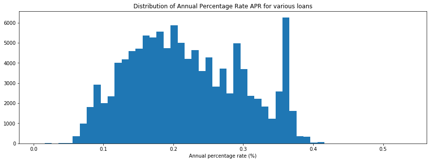

## Distribution of Loan Status

Most Loans are currently on going with no due payments, followed by a high amount of completed loans and few Past Due, Defualted, and Charged off loans, we have very little data on Cancelled and Final Payment in progress loans.

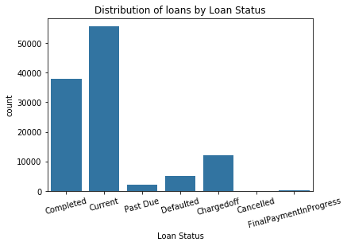

## BorrowerAPR vs Loan Status

Loans that were Past Due, Defualted, and Charged off had a Higher average APR, while current and completed loans had lower APR.

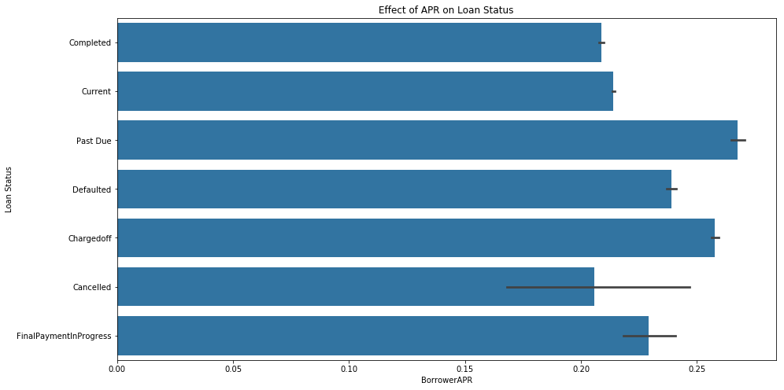

## DebtToIncomeRatio vsLoan Status | AvailableBankcardCredit and AvailableBankcardCredit vs Prosper Rating

Loans that were Past Due, Defualted, and Charged off were by people with a higher debt income ratio. A high available bank credit is associated with low debt income ratio, while a low available bank credit is associated with a high debt income ratio. The bank credits also has a strong effect on prosper ratings, high prosper ratings are given to loans with high available bank credit. All this would mean that a person with little money might have high debt income ratio, have a low rating and may not be able to complete a loans payment

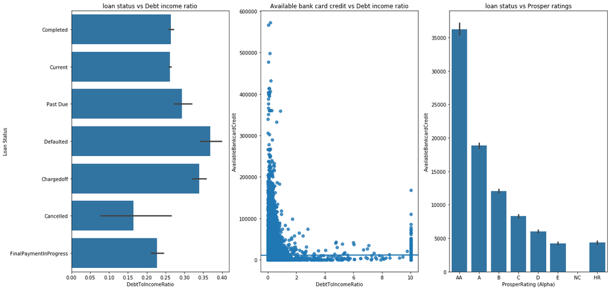

## BorrowerAPR vs Prosper rating

BorrowerAPR decreases with increase in prosper ratings(or high ratings AA, A, B) and is high or increases for low ratings. This shows that the rating given by the company has strong effect on the charges or rates of a loan.

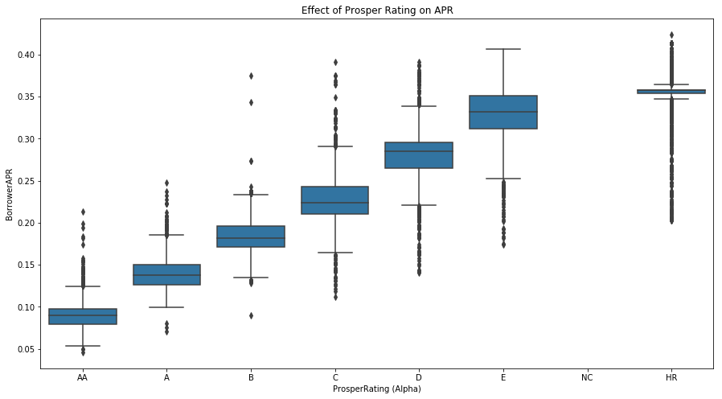

## BorrowerAPR vs Loan amount by Prosper rating

First, an increase in loan amount leads to a decrease in APR, while a decrease in loan amount leads to an increase in APR. The APR decreases with higher rating. Although most of the loan data are low, the loan amount increases with higher prosper ratings.

With better ratings from AA to A, the higher the Loan amount the higher the APR, this may have been so becuase people with high ratings may be able to pay high charges hence more profit for the loan company. While from B to HR ratings, the higher the loan amount the lower the APR. This may have been done to allow people who request for small loans to request for even more due to pay lesser charges on loans.

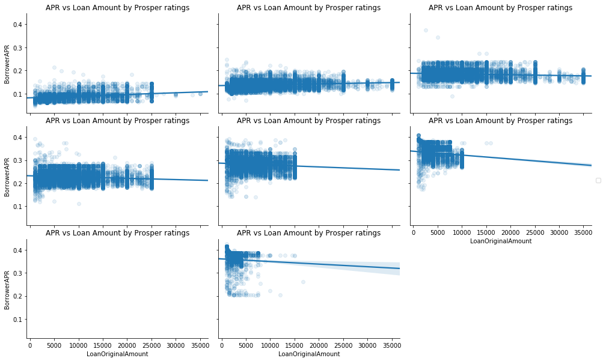

## BorrowerAPR vs Prosper Ratings by Term

A borrower having a high rating and short term will pay less charges on a loan(for AA - B). If a borrower has a low rating(C - HR), it will be better to have a longer term to pay less charges or have a lower APR on loan, althogh it can not be as low as the later.

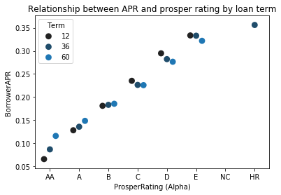